# Proof of concept: filtering pipeline (Clustering quality)

Paul Deveau

2016-08-11

# Creating data

This script is to show the importance of clustering high confidence variants and then attribute meaningful ones to the identified clusters

We will first create a test set with 6 clones, 200 variants, diploid, with an average depth of 100X, two samples with respective purity 70% and 60%.

```r
toy.data<-QuantumCat(number_of_clones = 6,number_of_mutations = 200,
                     ploidy = "AB",depth = 100,number_of_samples = 2,
                     contamination = c(0.3,0.4))
```

We check that all these variants are within the stringent filters (i.e depth > 50X):

```r
sum(toy.data[[1]]$Depth<=50)
```

```
## [1] 39
```

```r
sum(toy.data[[2]]$Depth<=50)
```

```
## [1] 31
```

We will remove these positions from the filtered data.

```r
keep<- sapply(X = 1:nrow(toy.data[[1]]),
              FUN = function (z){
                toy.data[[1]][z,"Depth"]>50 && toy.data[[2]][z,"Depth"]>50
              })

filtered.data<-lapply(X = toy.data, function(df){
  df[keep,]
})

knitr::kable(head(filtered.data[[1]]))
```

| Chr | Start | Genotype | Cellularit | number_of_copies | Frequency | Depth | Alt |
| --- | --- | --- | --- | --- | --- | --- | --- |
| 1 | 1 | AB | 100 | 1 | 35.00 | 110 | 45 |
| 6 | 2 | AB | 23 | 1 | 8.05 | 223 | 17 |
| 2 | 3 | AB | 29 | 1 | 10.15 | 106 | 12 |
| 1 | 4 | AB | 100 | 1 | 35.00 | 135 | 48 |
| 2 | 5 | AB | 29 | 1 | 10.15 | 76 | 5 |
| 6 | 6 | AB | 23 | 1 | 8.05 | 137 | 14 |

According to permissive filters, variants should have at least 30X depth of coverage. A total of 14 positions are not meeting that requirement. We also state that if the number of variants is sufficient, only AB site are kept. We thus add 150 positions that fall inside triploid - AAB - loci (with a 3/4 chance to be at 1 copy), and 50 that fall inside a tetraploid - AABB - locus (with a 50% chance to be at 1 copy).

```r
noisy_data<-toy.data

Chr<-sample(1:6,size = 200,replace = TRUE)
Start <- (nrow(noisy_data[[1]])+1):(nrow(noisy_data[[1]])+200)
purity<-c(0.7,0.6)
for(i in 1:length(toy.data)){
  Cells<-sapply(1:6, function(z) unique(noisy_data[[i]]$Cellularit[noisy_data[[i]]$Chr==z]))

  Genotype <-rep(c("AAB","AABB"),times = c(150,50))
  NCh<-rep(c(3,4),times = c(150,50))

  number_of_copies<-c(sample(x = 1:2,size = 150,replace = TRUE,prob = c(3/4,1/4)),
                      sample(x = 1:2,size = 50,replace = TRUE)
  )
  Cellularit<-sapply(Chr,function(n) Cells[n])
  Frequency <- Cellularit*purity[i]*number_of_copies/NCh
  Depth<-rnbinom(n=200,size = 4.331601,mu = 100)
  Alt<-rbinom(n=200,size = Depth,prob = Frequency/100)
  noisy_data[[i]]<-rbind(noisy_data[[i]],
                         data.frame(Chr = Chr,Start = Start,Genotype = Genotype,
                                    Cellularit = Cellularit,
                                    number_of_copies = number_of_copies,
                                    Frequency = Frequency, Depth = Depth, Alt = Alt))
}
```

Now let’s select 20 drivers among these ($1/4$ in stringent filters and $3/4$ in more noisy data):

```r
drivers<-c(sample(x = which(keep),size = round(ndrivers/4),replace = FALSE),
           sample(x = (1:nrow(noisy_data[[1]]))[!keep],size= 3*round(ndrivers/4),replace = FALSE)
)
```

5 are inside the stringent filter, and 15 fall in the permissive filters.

# Comparing different pipeline of clustering

## Measures

The first one will cluster variants from stringent filters and attribute drivers to the clusters found. The second will co-cluster all variants altogether. The final one will cluster filtered data and drivers altogether.

## Reconstruction

First we will set each function to work as previously described:

```r
paper_pipeline<-function(cleaned.data, drivers){
  Clusters<-One_step_clustering(SNV_list = filtered.data,
                                contamination = c(0.3,0.4),
                                nclone_range = 2:10,
                                maxit = 2,
                                save_plot = FALSE,
                                ncores = 4
  )
  #print(drivers)
  p<-Probability.to.belong.to.clone(SNV_list = drivers,
                                    clone_prevalence = Clusters$EM.output$centers,
                                    contamination = c(0.3,0.4),
                                    clone_weights = Clusters$EM.output$weights
  )
  return(list(Clusters = Clusters,Driver_clusts = p))
}

All_clustering<-function(noisy){
  return(One_step_clustering(SNV_list = noisy,
                             contamination = c(0.3,0.4),
                             nclone_range = 2:10,
                             maxit = 2,
                             save_plot = FALSE,
                             ncores = 4
  )
  )
}

filter_drivers<-function(cleaned.data,noisy_data,id_drivers_less_stringent){
  input<-list()
  test<-noisy_data[[1]]$Start %in% id_drivers_less_stringent
  for(i in 1:length(cleaned.data)){
    spare<-noisy_data[[i]][test,]
    row.names(spare)<-(max(as.numeric(row.names(cleaned.data[[1]])))+1):(max(as.numeric(row.names(cleaned.data[[1]])))+nrow(spare))
    input[[i]]<-rbind(cleaned.data[[i]],spare)
    row.names(input[[i]])<-1:nrow(input[[i]])
  }
  return(One_step_clustering(SNV_list = input,
                             contamination = c(0.3,0.4),
                             nclone_range = 2:10,
                             maxit = 2,
                             save_plot = FALSE,
                             ncores = 4
  ))
}
```

Let’s cluster the data with each pipeline:

```r
Paper_pipeline<-paper_pipeline(cleaned.data = filtered.data,drivers = drivers_data)
All<-All_clustering(noisy = noisy_data)
Filter_drivers<-filter_drivers(cleaned.data = filtered.data,
                               noisy_data,
                               id_drivers_less_stringent)
```

Now we will compare a few things: maximal error on the cellularity of a driver, maximal error on the distance of the cluster to the clone, and finally the normalized mutual information.

We can now summarize the different measures and pipelines:

| NMI | Maximal.Error.Cluster.Distance | Number.Clusters.Found | Maximal.Error.Driver.Distance | Mean.Error.Driver.Distance | id |
| --- | --- | --- | --- | --- | --- |
| 0.7068713 | 0.1447364 | 7 | 0.5593710 | 0.1112014 | Paper_pipeline |
| 0.6626749 | 0.1359517 | 6 | 0.4543807 | 0.0925434 | All |
| 0.6557564 | 0.1225477 | 7 | 0.5546298 | 0.1062358 | Filter_drivers |

Now, we are going to reproduce this on 9 new samples.

```r
source("reproduce.R")

repro<-reproduce(number_iterations-1)
Summ<-rbind(Summ,repro)

knitr::kable(Summ)
```

| NMI | Maximal.Error.Cluster.Distance | Number.Clusters.Found | Maximal.Error.Driver.Distance | Mean.Error.Driver.Distance | id |
| --- | --- | --- | --- | --- | --- |
| 0.7068713 | 0.1447364 | 7 | 0.5593710 | 0.1112014 | Paper_pipeline |
| 0.6626749 | 0.1359517 | 6 | 0.4543807 | 0.0925434 | All |
| 0.6557564 | 0.1225477 | 7 | 0.5546298 | 0.1062358 | Filter_drivers |
| 0.7244967 | 0.1663943 | 8 | 0.4776904 | 0.1841773 | Paper_pipeline |
| 0.4904619 | 0.2951988 | 10 | 0.2091183 | 0.0602317 | All |
| 0.5602877 | 0.1781619 | 8 | 0.2091743 | 0.0886665 | Filter_drivers |
| 0.6651303 | 0.1712926 | 9 | 0.4571402 | 0.2248673 | Paper_pipeline |
| 0.6236083 | 0.1764710 | 9 | 0.2573742 | 0.0734752 | All |
| 0.7579168 | 0.1683335 | 9 | 0.2321855 | 0.0546601 | Filter_drivers |
| 0.7437116 | 0.0665892 | 6 | 0.4900422 | 0.1484008 | Paper_pipeline |
| 0.6405289 | 0.2692911 | 9 | 0.2027242 | 0.0484593 | All |
| 0.8266264 | 0.1022459 | 7 | 0.2156871 | 0.0499908 | Filter_drivers |
| 0.6750436 | 0.1353742 | 9 | 0.4451678 | 0.1901252 | Paper_pipeline |
| NA | 0.6503249 | 8 | 0.5246186 | 0.0984576 | All |
| 0.6082660 | 0.1383683 | 6 | 0.3156867 | 0.0934884 | Filter_drivers |
| 0.7437116 | 0.0662680 | 6 | 0.3428820 | 0.1970720 | Paper_pipeline |
| 0.5840482 | 0.0989205 | 10 | 0.3302005 | 0.0482564 | All |
| 0.7583960 | 0.0507603 | 6 | 0.1328802 | 0.0302054 | Filter_drivers |
| 0.6899006 | 0.1333346 | 7 | 0.7517572 | 0.2928008 | Paper_pipeline |
| 0.6605985 | 0.1058089 | 6 | 0.4242722 | 0.0635670 | All |
| 0.7217715 | 0.2741007 | 8 | 0.4101992 | 0.0532247 | Filter_drivers |
| 0.7018036 | 0.1130720 | 7 | 0.6830588 | 0.1883377 | Paper_pipeline |
| 0.7968145 | 0.0252612 | 6 | 0.5199746 | 0.0329624 | All |
| 0.9360770 | 0.1703445 | 8 | 0.4960032 | 0.0456719 | Filter_drivers |
| 0.6690896 | 0.1659319 | 9 | 0.7263754 | 0.1517499 | Paper_pipeline |
| 0.4865545 | 0.1478449 | 9 | 0.2470877 | 0.0871934 | All |
| 0.6413476 | 0.1140518 | 10 | 0.2208019 | 0.0728263 | Filter_drivers |
| 0.6946564 | 0.1381636 | 8 | 0.8945486 | 0.2542666 | Paper_pipeline |
| 0.6806170 | 0.3399206 | 8 | 0.0822264 | 0.0295318 | All |
| 0.7349791 | 0.0541474 | 7 | 0.7080678 | 0.0719533 | Filter_drivers |

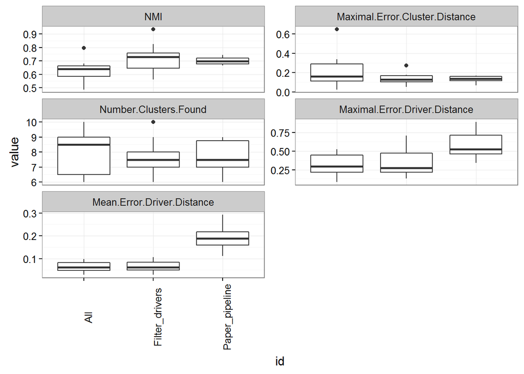

```r
Melt<-melt(cbind(Summ),id = "id")
Melt$value<-as.numeric(as.character(Melt$value))

ggplot(Melt,aes_string(x= "id",y = "value",facet = "variable"))+geom_boxplot()+facet_wrap( ~ variable,nrow = floor(sqrt(length(unique(Melt$variable))))+1,scales = "free_y")+theme_bw()+theme(axis.text.x = element_text(angle = 90))
```